# hw2_HaoLiu

```python
import numpy as np
import tensorflow as tf
import matplotlib.pyplot as plt
```

```python
from IPython.display import Image
```

### Feedforward

Consider the rectified linear activation function : hj = max(0, aj ).

1. Draw a network with: 2 inputs 1 hidden layers with 4 hidden units and a 1-class output (for binary classification)

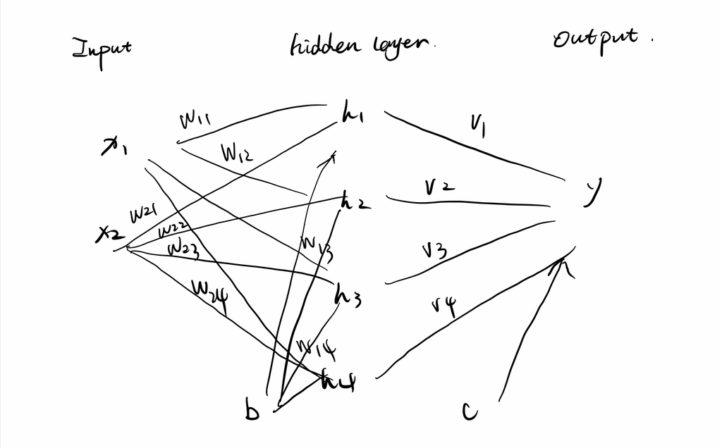

```python
Image(filename='1.jpeg')
```

1. Write out the mathematical equation for the output of this network

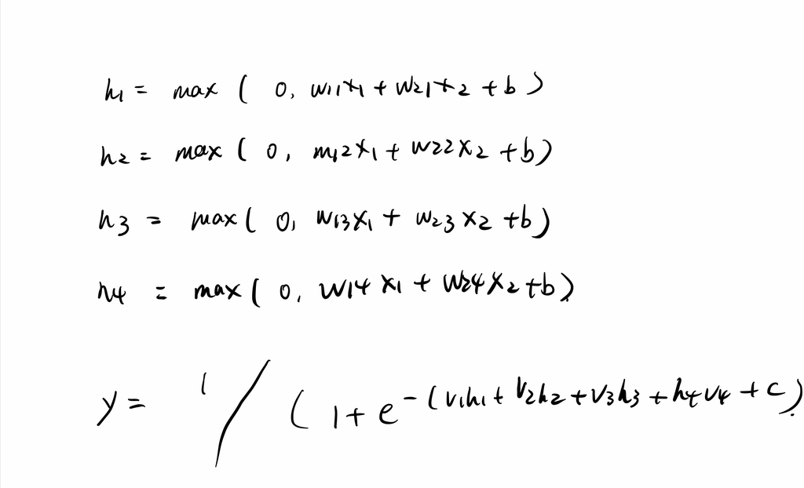

```python
Image(filename='2.jpeg')
```

1. Write out the forward-pass function in python, call it ff nn ReLu(...)

```python
def ff_nn_ReLu(x,w,b):
    temp = np.dot(w,x)
    return tf.nn.relu(temp)
```

```python
def take_out(x,w,b,v,c):
    h = ff_nn_ReLu(x,w,b)
    return tf.nn.sigmoid(np.dot(v,h)+c)
```

1. what are the class probabilities associated with the forward pass of each sample?

```python
x = np.array([[1,0,0],[-1,-1,1]])
w = np.array([[1,0],[-1,0],[0,0.5],[1,1]])
b = np.array([[0,0,1,0]]).T
v =np.array([[1,0,-1,1]])
c = [1]
```

```python
probabilities = take_out(x,w,b,v,c)
```

```python
probabilities
```

```
<tf.Tensor: shape=(1, 3), dtype=float64, numpy=array([[0.88079708, 0.73105858, 0.81757448]])>
```

The class probabilities asscociated with the forward pass of each sample are around 0.88, 0.73, 0.82

### Gradient Descent

1. What are the partial derivatives of f with respect to x and to y?

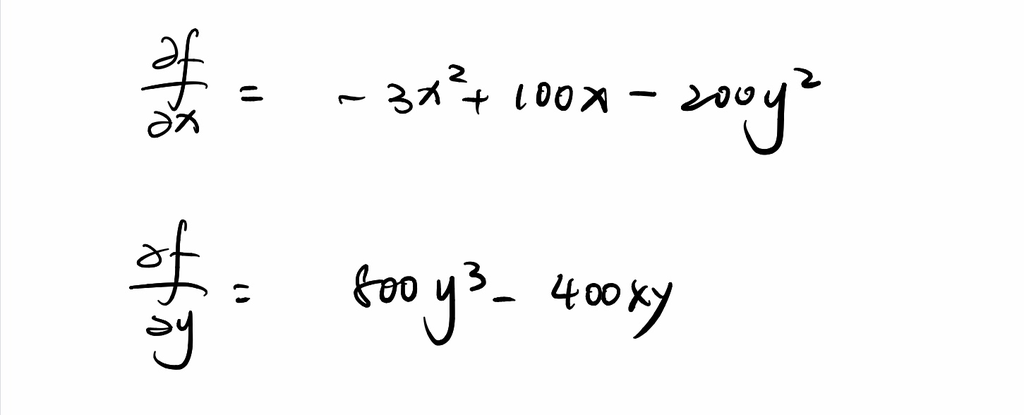

```python
Image(filename='3.jpeg')
```

1. Create a visualization of the contours of this function.

```python
def F(x,y):
    return (3 - x**3) + 50 * (2*y**2 - x)**2
```

```python
x = np.arange(-2,3,0.01)
y = np.arange(-2,3,0.01)
X,Y = np.meshgrid(x,y)
Z = F(X,Y)
```

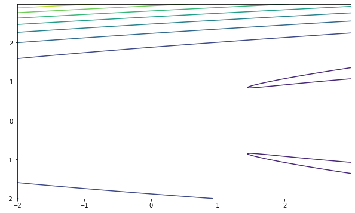

```python
plt.figure(figsize=(10,6))
plt.contour(X,Y,Z)
```

1. Write a Gradient Descent algorithm for finding the minimum of the function. Visualize your results with a few different learning rates.

```python
def grad_f(a):
    x,y = a
    dx = -3*x**2 + 100*x -200*y**2
    dy = 800*y**3 - 400*x*y
    return np.array([dx, dy])
```

```python
def gradient_descent(start_point, iterations, learning_rate):
    current = start_point
    track = [current]
    for i in range(iterations):
        cur_grad = grad_f(current)
        current = current - learning_rate * cur_grad
        track.append(current)
    return np.array(track)
```

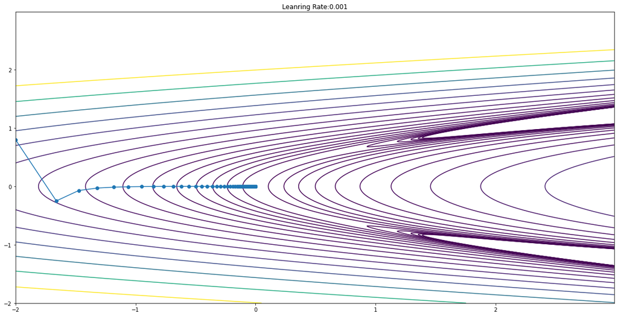

```python
traj = gradient_descent(start_point=[-2,0.8] , iterations=100, learning_rate=0.001)
plt.figure(figsize=(20,10))
plt.contour(X,Y,Z,np.logspace(-0.5,3.5,20,base=10))
plt.title('Leanring Rate:0.001')
x= traj[:,0]
y= traj[:,1]
plt.plot(x,y,'-o')
```

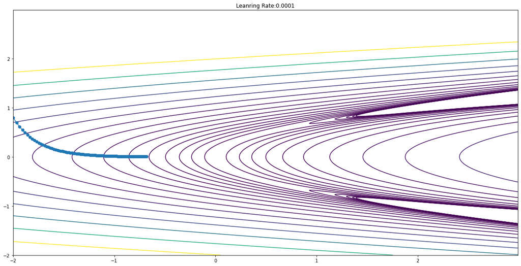

```python
traj = gradient_descent(start_point=[-2,0.8] , iterations=100, learning_rate=0.0001)
plt.figure(figsize=(20,10))
plt.contour(X,Y,Z,np.logspace(-0.5,3.5,20,base=10))
plt.title('Leanring Rate:0.0001')
x= traj[:,0]
y= traj[:,1]
plt.plot(x,y,'-o')
```

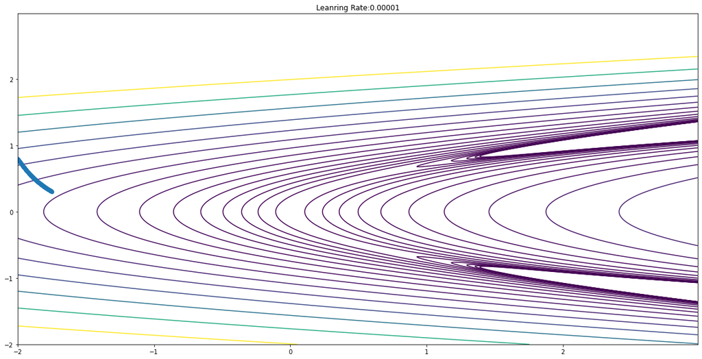

```python
traj = gradient_descent(start_point=[-2,0.8] , iterations=100, learning_rate=0.00001)
plt.figure(figsize=(20,10))
plt.contour(X,Y,Z,np.logspace(-0.5,3.5,20,base=10))
plt.title('Leanring Rate:0.00001')
x= traj[:,0]
y= traj[:,1]
plt.plot(x,y,'-o')
```

1. Write a Gradient Descent With Momentum algorithm for finding the minimum. Visualize your results with a few different settings of the algorithm’s hyperparameters.

```python
def gradient_descent_momentum(start_point, iterations, learning_rate, alpha, v):
    current_point = start_point
    track = [current_point]
    velocity = v
    for i in range(iterations):
        cur_grad = grad_f(current_point)
        if (abs(cur_grad[0] < 0.001 and abs(cur_grad[1]) < 0.001)):
            return np.array(track)
        velocity = alpha * velocity - learning_rate * cur_grad
        current_point = current_point + velocity
        track.append(current_point)
    return np.array(track)
```

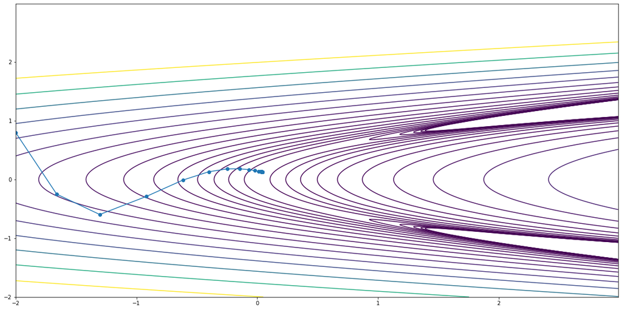

```python
traj = gradient_descent_momentum(iterations=100, learning_rate=0.001, start_point=[-2,0.8], alpha = 0.5, v = np.array([0,0]))
plt.figure(figsize=(20,10))
plt.contour(X,Y,Z,np.logspace(-0.5,3.5,20,base=10))
x= traj[:,0]
y= traj[:,1]
plt.plot(x,y,'-o')
```

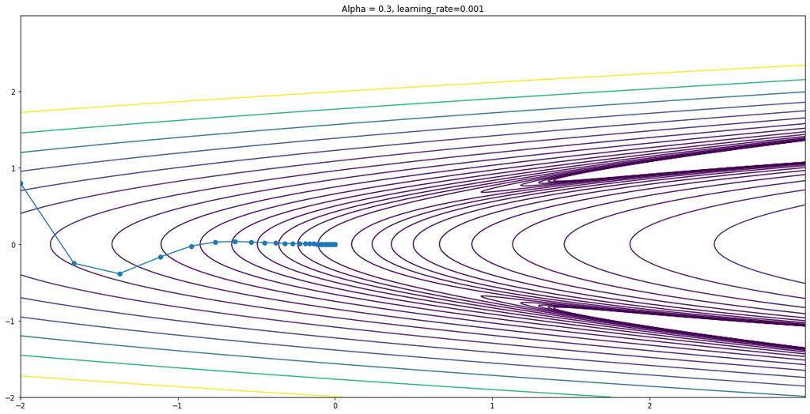

```python
traj = gradient_descent_momentum(iterations=100, learning_rate=0.001, start_point=[-2,0.8], alpha = 0.3, v = np.array([0,0]))
plt.figure(figsize=(20,10))
plt.title('Alpha = 0.3, learning_rate=0.001')
plt.contour(X,Y,Z,np.logspace(-0.5,3.5,20,base=10))
x= traj[:,0]
y= traj[:,1]
plt.plot(x,y,'-o')
```

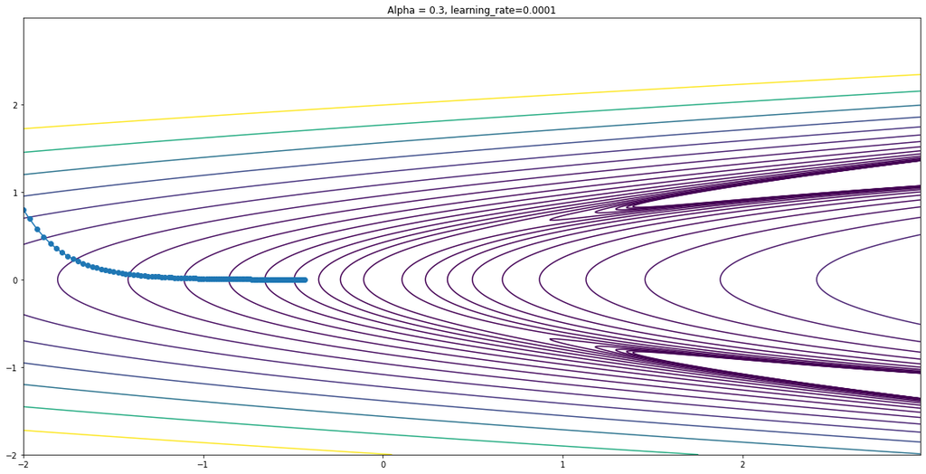

```python
traj = gradient_descent_momentum(iterations=100, learning_rate=0.0001, start_point=[-2,0.8], alpha = 0.3, v = np.array([0,0]))
plt.figure(figsize=(20,10))
plt.title('Alpha = 0.3, learning_rate=0.0001')
plt.contour(X,Y,Z,np.logspace(-0.5,3.5,20,base=10))
x= traj[:,0]
y= traj[:,1]
plt.plot(x,y,'-o')
```

### Backprop

1. For the same network as in Question 1, derive expressions of the gradient of the Loss function with respect to each of the model parameters.

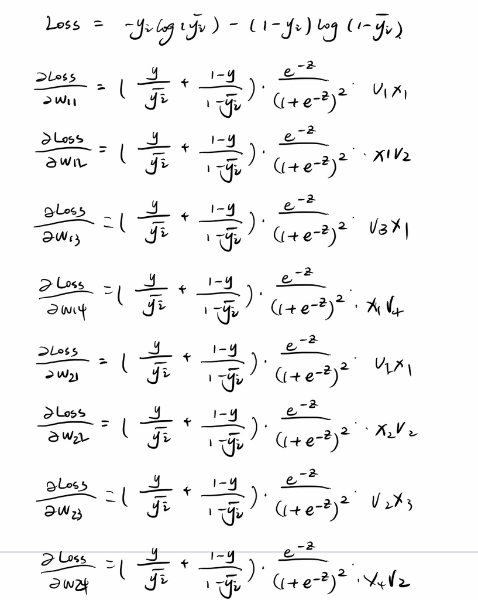

```python
Image(filename='4.jpeg')
```

1. Write a function grad f(...) that takes in a weights vector and returns the gradient of the Loss at that location.

```python
def new_output(X,params):
    h = tf.nn.relu(tf.matmul(params[0],X)+params[1])
    return tf.nn.sigmoid(tf.matmul(params[2],h)+params[3])
loss = tf.keras.losses.BinaryCrossentropy()
```

```python
def grad_f(X,Y,params):
    with tf.GradientTape() as tape:
        y_hat = new_output(X,params)
        f = loss(Y,y_hat)
    print(tape.gradient(f,params))
```

```python
W = tf.random.uniform((4, 2), minval=-1, maxval=1)
B = tf.random.uniform((4, 1), minval=-1, maxval=1)
V = tf.random.uniform((1, 4), minval=-1, maxval=1)
C = tf.random.uniform((1,), minval=-1, maxval=1)
X = tf.random.uniform((2,3), minval=-2, maxval=2)
Y = tf.constant([0,0,1])
params = [tf.Variable(p) for p in [W,B,V,C]]
```

```python
grad_f(X,Y,params)
```

```
[<tf.Tensor: shape=(4, 2), dtype=float32, numpy=
array([[ 0.        ,  0.        ],
       [ 0.        ,  0.        ],
       [ 0.        ,  0.        ],
       [ 0.00306355, -0.04702618]], dtype=float32)>, <tf.Tensor: shape=(4, 1), dtype=float32, numpy=
array([[ 0.        ],
       [ 0.        ],
       [ 0.        ],
       [-0.04567233]], dtype=float32)>, <tf.Tensor: shape=(1, 4), dtype=float32, numpy=array([[0.        , 0.        , 0.        , 0.19049744]], dtype=float32)>, <tf.Tensor: shape=(1,), dtype=float32, numpy=array([0.29476008], dtype=float32)>]
```

1. Generate a synthetic dataset like the XOR pattern (see below).

```python
def binary_classification_data(N):
    X = np.random.uniform(low=-2, high=2, size=(N, 2)).astype(np.float32)
    Y = (X[:, 0] * X[:, 1] > 0).astype(np.int)
    return X,Y
```

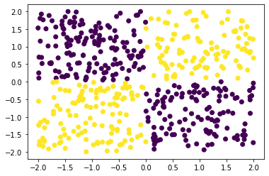

```python
X,Y = binary_classification_data(500)
plt.scatter(X[:, 0],X[:, 1],c=Y)
```

1. Fit your network using Gradient Descent. Keep track of the total Loss at each iteration and plot the result.

```python
def grad_step(X,Y,params,step_size):
    with tf.GradientTape() as tape:
        y_hat = ff_nn_new(X,params)
        f = loss(Y,y_hat)
    grads = tape.gradient(f,params)
    for var,grad in zip(params,grads):
        var.assign(var - step_size*grad)
    return f
```

```python
def grad_desc(X,Y,params,step_size,n_iters):
    X = tf.Variable(X.T)
    Y = tf.Variable(Y)
    W = tf.random.uniform((4.0, 2.0), minval=-1, maxval=1)
    B = tf.random.uniform((4.0, 1.0), minval=-1, maxval=1)
    V = tf.random.uniform((1.0, 4.0), minval=-1, maxval=1)
    C = tf.random.uniform((1.0,), minval=-1, maxval=1)
    params = [tf.Variable(p) for p in [W,B,V,C]]
    losses = []
    for i in range(n_iters):
        losses.append(grad_step(X,Y,params,step_size))
    return losses,params
```

```python
losses,params =grad_desc(X,Y,params,0.1,10000)
plt.plot(losses)
plt.show()
```

[output not shown]

[output not shown]